# VPKSR_Survey_PhilHerman

RobertChapman

2023-12-12

### Analyis plan from Phil 12/4

#### SR

*Analysis 1: Price of Care a prohibitive factor* <- CTree

Outcome variable: Childcare too expensive, coded as dichotomous (either too expensive or not)  
Predictors: Marital status, (combining married & living with partners), income, # of children needing care, preferred amount of money, transportation, ages of children needing care (collapsing across all ages - one value per row), parent education

*Analysis 2: Cross tabs/descriptives*  
1) Preferred distance by mode of transportation and people who did/didnt endorse pref for ‘conveniently located’

```r
    DistancebyTransModeforNotConvLocatedTrue=table(
        data$SRCombined$PrimaryTransportationMode[
          grep("*conveniently located*",data$SRCombined$TroubleFindingChildcare, invert=FALSE)],
        data$SRCombined$PreferredTravelDistance[
          grep("*conveniently located*",data$SRCombined$TroubleFindingChildcare, invert=FALSE)])
      write.csv(DistancebyTransModeforNotConvLocatedTrue, "SR_xtabs_PrefDistbyTranspMode_NotConvLocTRUE.csv")

    #Distance by Transportation Mode table for Not Conveniently Located = True
      datatable(matrix(DistancebyTransModeforNotConvLocatedTrue, ncol = ncol(DistancebyTransModeforNotConvLocatedTrue), dimnames = dimnames(DistancebyTransModeforNotConvLocatedTrue)), caption="Distance by Transportation Mode table for Not Conveniently Located = True")
```

|  | 10 to 20 minutes | 5 to 10 minutes |
| --- | --- | --- |
| Bus or other public transportation | 2 | 1 |
| Personal motor vehicle | 3 | 3 |
| Walking | 0 | 1 |

```r
      DistancebyTransModeforNotConvLocatedFalse=table(
        data$SRCombined$PrimaryTransportationMode[
          !grepl("*conveniently located*",data$SRCombined$TroubleFindingChildcare)],
        data$SRCombined$PreferredTravelDistance[
          !grepl("*conveniently located*",data$SRCombined$TroubleFindingChildcare)])

         write.csv(DistancebyTransModeforNotConvLocatedFalse, "SR_xtabs_PrefDistbyTranspMode_NotConvLocFALSE.csv")

      #Distance by Transportation Mode table for Not Conveniently Located = False
      datatable(matrix(DistancebyTransModeforNotConvLocatedFalse, ncol = ncol(DistancebyTransModeforNotConvLocatedFalse), dimnames = dimnames(DistancebyTransModeforNotConvLocatedFalse)), caption="Distance by Transportation Mode table for Not Conveniently Located = False")
```

|  | 10 to 20 minutes | 20 to 30 minutes | 5 to 10 minutes | Less than 5 minutes |
| --- | --- | --- | --- | --- |
| Bus or other public transportation | 4 | 0 | 8 | 1 |
| Carpool with friends, family, or coworkers | 0 | 0 | 5 | 4 |
| Paid rideshare (for example: Uber, Lyft, etc.) | 0 | 0 | 3 | 0 |
| Personal motor vehicle | 16 | 6 | 51 | 16 |
| Walking | 1 | 0 | 1 | 3 |

2. Provider quality with parent education

```r
NotQualitybyEducation=table(data$SRCombined$Education, "Provider Not High Quality"=grepl("*quality*",data$SRCombined$TroubleFindingChildcare))

write.csv(NotQualitybyEducation,"SR_xtabs_EducationbyProviderNotQuality.csv")

#Education by Provider Not High Quality
      datatable(matrix(NotQualitybyEducation, ncol = ncol(NotQualitybyEducation), dimnames = dimnames(NotQualitybyEducation)), caption="Education by Provider Not High Quality")
```

|  | FALSE | TRUE |
| --- | --- | --- |
| 8th grade or less | 3 | 0 |
| 9th-12th grade (no high school diploma) | 10 | 1 |
| Associate degree (AA, AS) | 15 | 1 |
| Bachelor’s degree (BA, BS, AB) | 6 | 2 |
| Graduate or professional degree | 5 | 0 |
| High school graduate or GED completed | 42 | 3 |
| Some college credit but no degree | 39 | 2 |

3. “Provider not open during hours I need” vs Ranges for open/closed preferences

```r
TotalNotOpenHoursNeededbyBusinessHours=table("Provider Not Open Hours I need"=grepl("*hours*",data$SRCombined$TroubleFindingChildcare),
"Preferred Hours Outside 7a-6p"=(data$SRCombined$ProviderOpensAM<"7:00"|data$SRCombined$ProviderClosesPM>"6:00"))

TotalNotOpenHoursNeededbyBusinessHours
```

```
##                               Preferred Hours Outside 7a-6p
## Provider Not Open Hours I need FALSE TRUE
##                          FALSE    54   64
##                          TRUE      2    6
```

```r
ProviderHoursbyNotOpenHoursNeededTrue=table("Opens AM"=data$SRCombined$ProviderOpensAM[grep("*hours*",data$SRCombined$TroubleFindingChildcare)],
      "Closes PM"=data$SRCombined$ProviderClosesPM[grep("*hours*",data$SRCombined$TroubleFindingChildcare)])

write.csv(ProviderHoursbyNotOpenHoursNeededTrue,"SRxtabs_PrefHoursbyProvNotOpenHours.csv")

#Provider Hours by Not Open Hours Needed = True
      datatable(matrix(ProviderHoursbyNotOpenHoursNeededTrue, ncol = ncol(ProviderHoursbyNotOpenHoursNeededTrue), dimnames = dimnames(ProviderHoursbyNotOpenHoursNeededTrue)), caption="Provider Hours by Not Open Hours Needed = True ", options = list(pageLength = 25))
```

|  | 10:00 | 11:00 | 3:00 | 4:00 | 6:00 | 8:00 |
| --- | --- | --- | --- | --- | --- | --- |
| 5:00 | 0 | 0 | 0 | 0 | 1 | 0 |
| 6:00 | 0 | 2 | 1 | 0 | 1 | 1 |
| 7:00 | 1 | 0 | 0 | 0 | 0 | 0 |
| 8:00 | 0 | 0 | 0 | 0 | 1 | 0 |

```r
ProviderHoursbyNotOpenHoursNeededFalse=table("Opens AM"=data$SRCombined$ProviderOpensAM[grep("*hours*",data$SRCombined$TroubleFindingChildcare, invert=TRUE)],
      "Closes PM"=data$SRCombined$ProviderClosesPM[grep("*hours*",data$SRCombined$TroubleFindingChildcare, invert=TRUE)])

write.csv(ProviderHoursbyNotOpenHoursNeededFalse,"SRxtabs_PrefHoursbyProvOpenHours.csv")

#Provider Hours by Not Open Hours Needed = False
      datatable(matrix(ProviderHoursbyNotOpenHoursNeededFalse, ncol = ncol(ProviderHoursbyNotOpenHoursNeededFalse), dimnames = dimnames(ProviderHoursbyNotOpenHoursNeededFalse)), caption="Provider Hours by Not Open Hours Needed = False ", options = list(pageLength = 25))
```

|  | 1:00 | 1:20 | 10:00 | 11:00 | 12:00 | 24 | 3:00 | 4:00 | 5:00 | 5:30 | 6:00 | 6:30 | 7:00 | 8:00 | 8:30 | 9:00 |
| --- | --- | --- | --- | --- | --- | --- | --- | --- | --- | --- | --- | --- | --- | --- | --- | --- |
| 1:00 | 0 | 0 | 0 | 0 | 1 | 0 | 0 | 0 | 0 | 0 | 0 | 0 | 0 | 0 | 0 | 0 |
| 10:00 | 0 | 0 | 0 | 0 | 0 | 0 | 0 | 0 | 0 | 0 | 1 | 0 | 0 | 0 | 0 | 0 |
| 11:00 | 0 | 0 | 0 | 1 | 0 | 0 | 0 | 0 | 0 | 0 | 0 | 0 | 0 | 0 | 0 | 0 |
| 2:30 | 0 | 0 | 0 | 0 | 0 | 0 | 0 | 0 | 0 | 0 | 1 | 0 | 2 | 0 | 0 | 0 |
| 24 | 0 | 0 | 0 | 0 | 0 | 1 | 0 | 0 | 0 | 0 | 0 | 0 | 0 | 0 | 0 | 0 |
| 3:00 | 0 | 0 | 0 | 0 | 0 | 0 | 0 | 0 | 0 | 0 | 1 | 0 | 0 | 0 | 0 | 0 |
| 5:00 | 0 | 0 | 0 | 0 | 0 | 0 | 1 | 0 | 1 | 0 | 0 | 0 | 0 | 0 | 0 | 1 |
| 5:30 | 0 | 0 | 0 | 0 | 0 | 0 | 0 | 0 | 0 | 0 | 1 | 0 | 0 | 0 | 0 | 0 |
| 6:00 | 1 | 0 | 1 | 0 | 0 | 0 | 1 | 1 | 2 | 1 | 21 | 1 | 4 | 2 | 0 | 0 |
| 6:30 | 0 | 0 | 0 | 0 | 0 | 0 | 0 | 0 | 0 | 1 | 4 | 2 | 0 | 0 | 1 | 0 |

[output cut: 6 more lines]

4. Ranges for open/closed preferences <- general for everyone

```r
GenProviderHours=table("Opens AM"=data$SRCombined$ProviderOpensAM,
      "Closes PM"=data$SRCombined$ProviderClosesPM)

write.csv(GenProviderHours,"SRxtabs_PrefHours.csv")

#General Provider Hours
      datatable(matrix(GenProviderHours, ncol = ncol(GenProviderHours), dimnames = dimnames(GenProviderHours)), caption="General Provider Hours", options = list(pageLength = 25))
```

|  | 1:00 | 1:20 | 10:00 | 11:00 | 12:00 | 24 | 3:00 | 4:00 | 5:00 | 5:30 | 6:00 | 6:30 | 7:00 | 8:00 | 8:30 | 9:00 |
| --- | --- | --- | --- | --- | --- | --- | --- | --- | --- | --- | --- | --- | --- | --- | --- | --- |
| 1:00 | 0 | 0 | 0 | 0 | 1 | 0 | 0 | 0 | 0 | 0 | 0 | 0 | 0 | 0 | 0 | 0 |
| 10:00 | 0 | 0 | 0 | 0 | 0 | 0 | 0 | 0 | 0 | 0 | 1 | 0 | 0 | 0 | 0 | 0 |
| 11:00 | 0 | 0 | 0 | 1 | 0 | 0 | 0 | 0 | 0 | 0 | 0 | 0 | 0 | 0 | 0 | 0 |
| 2:30 | 0 | 0 | 0 | 0 | 0 | 0 | 0 | 0 | 0 | 0 | 1 | 0 | 2 | 0 | 0 | 0 |
| 24 | 0 | 0 | 0 | 0 | 0 | 1 | 0 | 0 | 0 | 0 | 0 | 0 | 0 | 0 | 0 | 0 |
| 3:00 | 0 | 0 | 0 | 0 | 0 | 0 | 0 | 0 | 0 | 0 | 1 | 0 | 0 | 0 | 0 | 0 |
| 5:00 | 0 | 0 | 0 | 0 | 0 | 0 | 1 | 0 | 1 | 0 | 1 | 0 | 0 | 0 | 0 | 1 |
| 5:30 | 0 | 0 | 0 | 0 | 0 | 0 | 0 | 0 | 0 | 0 | 1 | 0 | 0 | 0 | 0 | 0 |
| 6:00 | 1 | 0 | 1 | 2 | 0 | 0 | 2 | 1 | 2 | 1 | 22 | 1 | 4 | 3 | 0 | 0 |
| 6:30 | 0 | 0 | 0 | 0 | 0 | 0 | 0 | 0 | 0 | 1 | 4 | 2 | 0 | 0 | 1 | 0 |

[output cut: 6 more lines]

#### VPK:

*No longer needed care*  
**Section 1: Sent kids to stay with family/friends**

Household Size distribution  
Income distribution  
marital status frequencies  
what responses do they select for reasons having trouble finding a provider

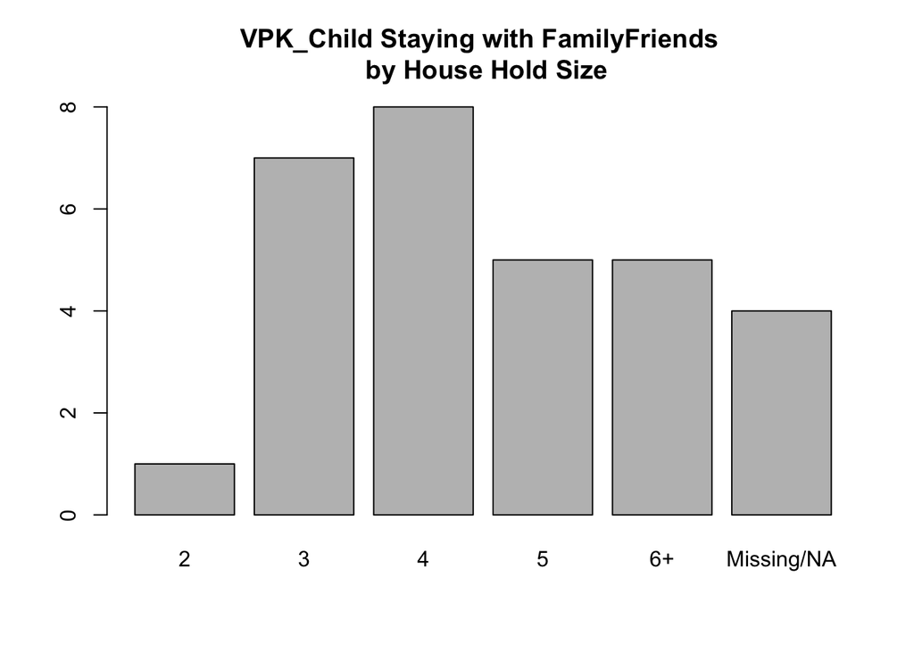

```r
Sect1Indx=grep("*I decided to have my child stay with family/friends*",data$VPKCombined$WhyNoLongerNeeded)

    VPKA1_HH_Size=PlotTabulate("HouseHoldSize", list("VPK_Child Staying with FamilyFriends"=data$VPKCombined[Sect1Indx,]))
    barplot(VPKA1_HH_Size[[1]]$freqtable,main="VPK_Child Staying with FamilyFriends \n by House Hold Size")
```

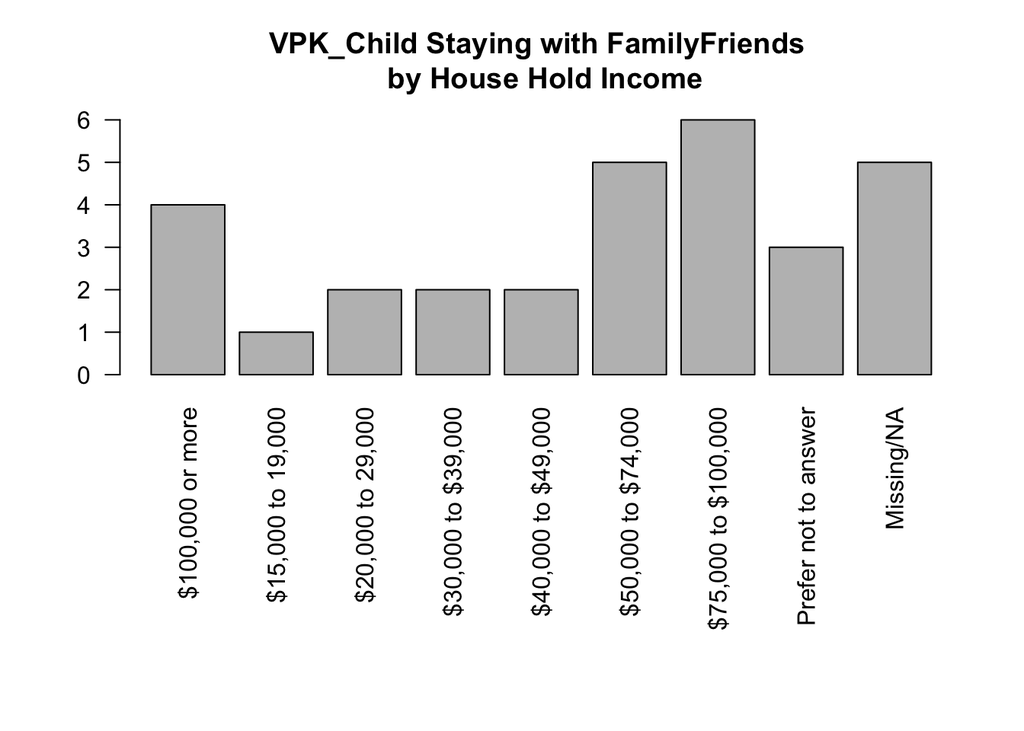

```r
    VPKA1_HH_Inc=PlotTabulate("HouseHoldIncome", list("VPK_Child Staying with FamilyFriends"=data$VPKCombined[Sect1Indx,]))
    par(mar = c(12.1, 4.1, 4.1, 2.1))
    par(las=2)
    barplot(VPKA1_HH_Inc[[1]]$freqtable, main="VPK_Child Staying with FamilyFriends \n by House Hold Income")
```

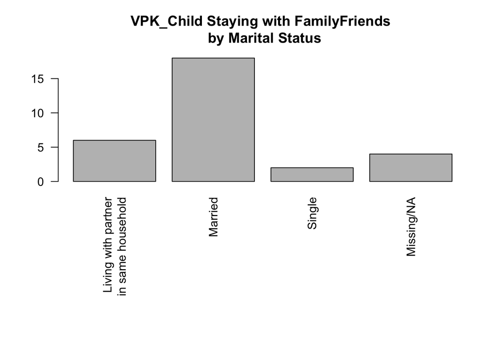

```r
    VPKA1_Marital=PlotTabulate("MaritalStatus", list("VPK_Child Staying with FamilyFriends"=data$VPKCombined[Sect1Indx,]))
    par(mar = c(12.1, 4.1, 4.1, 2.1))
    par(las=2)
    barplot(VPKA1_Marital[[1]]$freqtable, main="VPK_Child Staying with FamilyFriends \n by Marital Status")
```

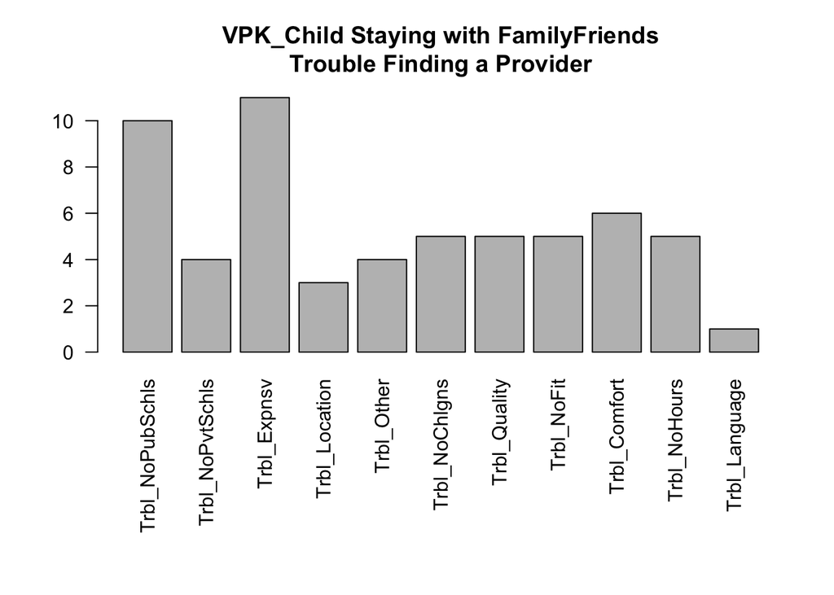

```r
    png("FamFriends_Trouble.png")
    par(mar = c(10.1, 4.1, 4.1, 2.1))
    par(las=2)
    barplot(apply(data$VPKCombined[Sect1Indx,grep("^Trbl",names(data$VPKCombined))], 2, function(c){sum(as.numeric(c),na.rm=TRUE)}))
    dev.off()

    par(mar = c(10.1, 4.1, 4.1, 2.1))
    par(las=2)
    barplot(apply(data$VPKCombined[Sect1Indx,grep("^Trbl",names(data$VPKCombined))], 2, function(c){sum(as.numeric(c),na.rm=TRUE)}), main="VPK_Child Staying with FamilyFriends\nTrouble Finding a Provider")
```

**Section 2: Stay at home with child**

Household Size distribution  
Income distribution  
marital status frequencies  
what responses do they select for reasons having trouble finding a provider

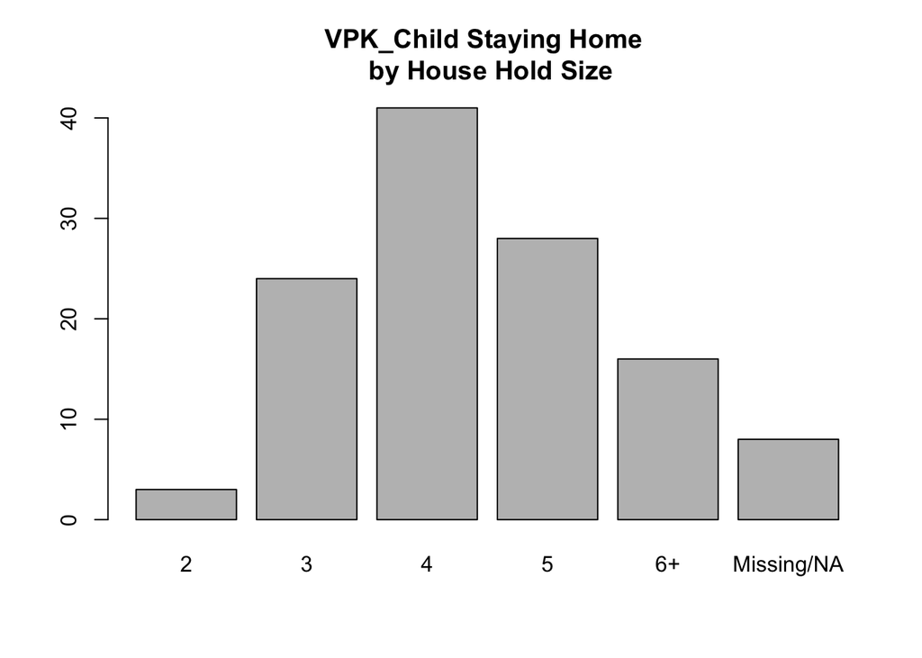

```r
Sect2Indx=grep("*I decided to stay home with my child*",data$VPKCombined$WhyNoLongerNeeded)

    VPKA2_HH_Size=PlotTabulate("HouseHoldSize", list("VPK_Child Staying Home"=data$VPKCombined[Sect2Indx,]))
    barplot(VPKA2_HH_Size[[1]]$freqtable,main="VPK_Child Staying Home \n by House Hold Size")
```

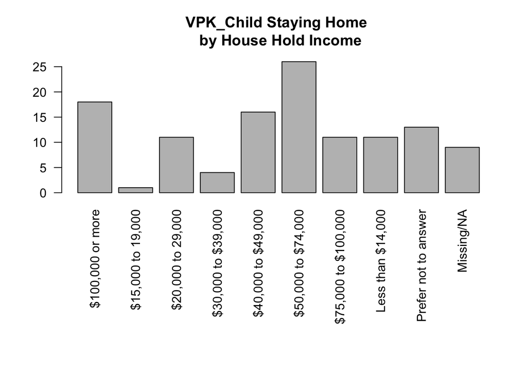

```r
    VPKA2_HH_Inc=PlotTabulate("HouseHoldIncome", list("VPK_Child Staying Home"=data$VPKCombined[Sect2Indx,]))
    par(mar = c(12.1, 4.1, 4.1, 2.1))
    par(las=2)
    barplot(VPKA2_HH_Inc[[1]]$freqtable, main="VPK_Child Staying Home \n by House Hold Income")
```

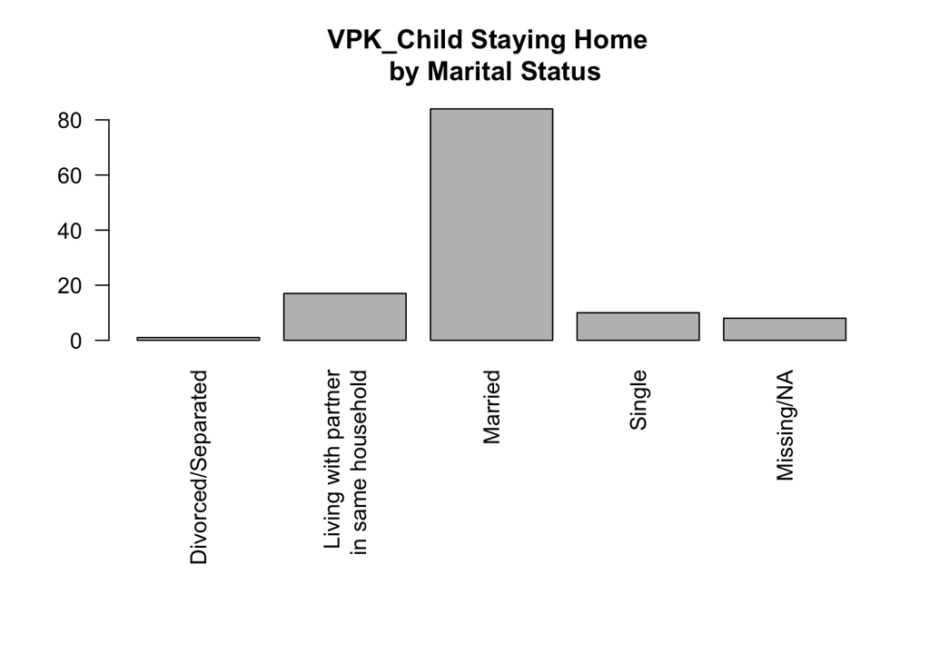

```r
    VPKA2_Marital=PlotTabulate("MaritalStatus", list("VPK_Child Staying Home"=data$VPKCombined[Sect2Indx,]))
    par(mar = c(12.1, 4.1, 4.1, 2.1))
    par(las=2)
    barplot(VPKA2_Marital[[1]]$freqtable, main="VPK_Child Staying Home \n by Marital Status")
```

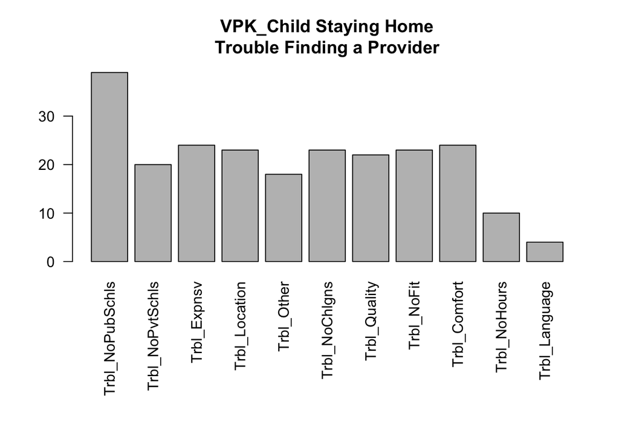

```r
    png("FamFriends_Trouble.png")
    par(mar = c(10.1, 4.1, 4.1, 2.1))
    par(las=2)
    barplot(apply(data$VPKCombined[Sect2Indx,grep("^Trbl",names(data$VPKCombined))], 2, function(c){sum(as.numeric(c),na.rm=TRUE)}))
    dev.off()

    par(mar = c(10.1, 4.1, 4.1, 2.1))
    par(las=2)
    barplot(apply(data$VPKCombined[Sect2Indx,grep("^Trbl",names(data$VPKCombined))], 2, function(c){sum(as.numeric(c),na.rm=TRUE)}), main="VPK_Child Staying Home\nTrouble Finding a Provider")
```

**Section 3: Alternative care**

Household Size distribution  
Income distribution  
marital status frequencies  
what responses do they select for reasons having trouble finding a provider

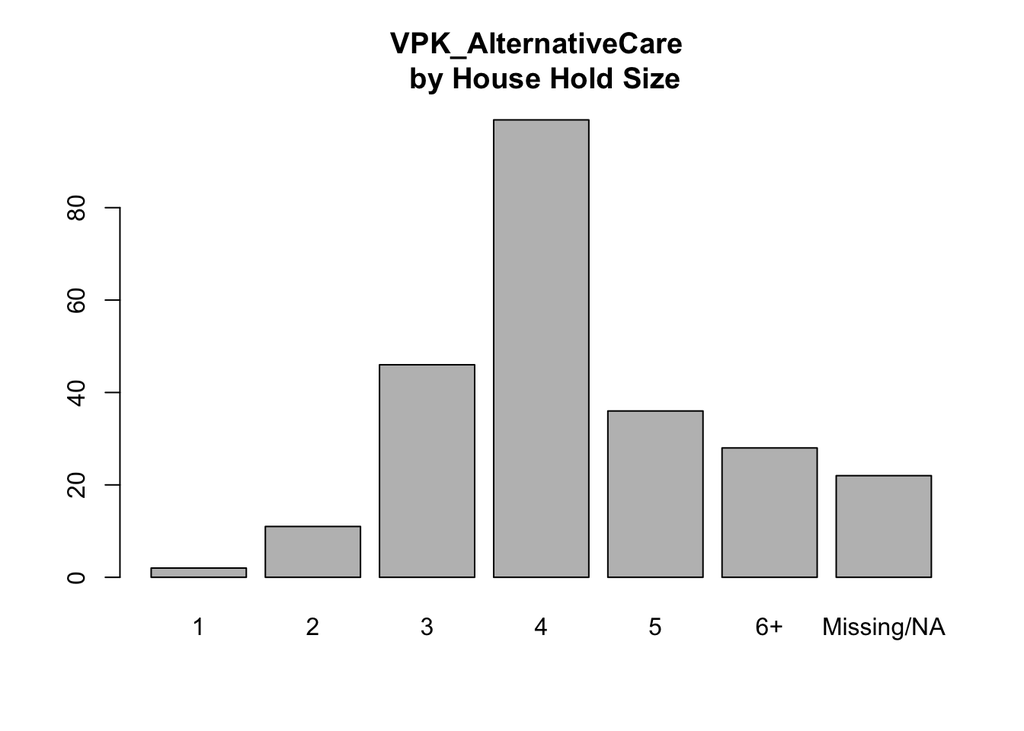

```r
Sect3Indx=grep("*alternative*",data$VPKCombined$WhyNoLongerNeeded)

    VPKA3_HH_Size=PlotTabulate("HouseHoldSize", list("VPK_AlternativeCare"=data$VPKCombined[Sect3Indx,]))
    barplot(VPKA3_HH_Size[[1]]$freqtable,main="VPK_AlternativeCare \n by House Hold Size")
```

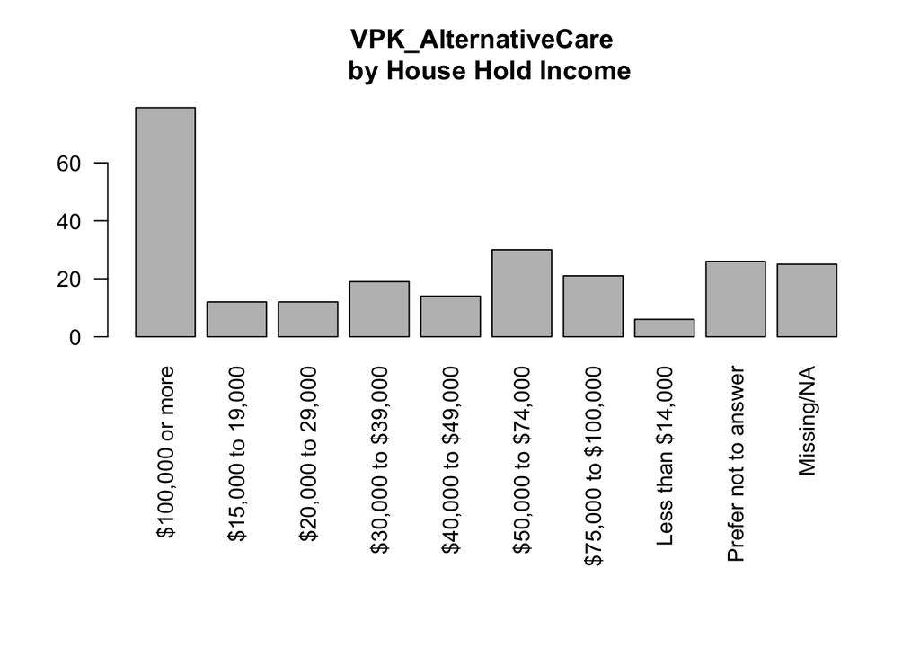

```r
    VPKA3_HH_Inc=PlotTabulate("HouseHoldIncome", list("VPK_AlternativeCare"=data$VPKCombined[Sect3Indx,]))
    par(mar = c(12.1, 4.1, 4.1, 2.1))
    par(las=2)
    barplot(VPKA3_HH_Inc[[1]]$freqtable, main="VPK_AlternativeCare \n by House Hold Income")
```

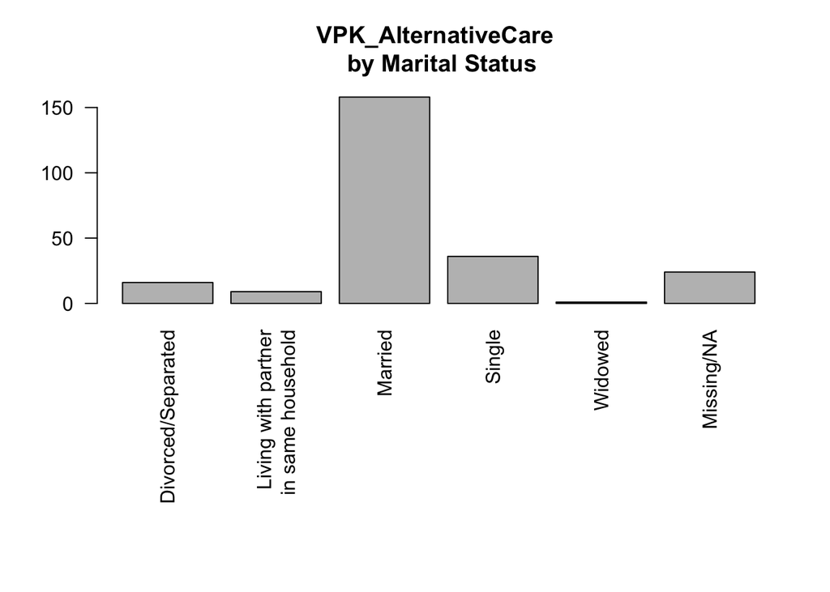

```r
    VPKA3_Marital=PlotTabulate("MaritalStatus", list("VPK_AlternativeCare"=data$VPKCombined[Sect3Indx,]))
    par(mar = c(12.1, 4.1, 4.1, 2.1))
    par(las=2)
    barplot(VPKA3_Marital[[1]]$freqtable, main="VPK_AlternativeCare \n by Marital Status")
```

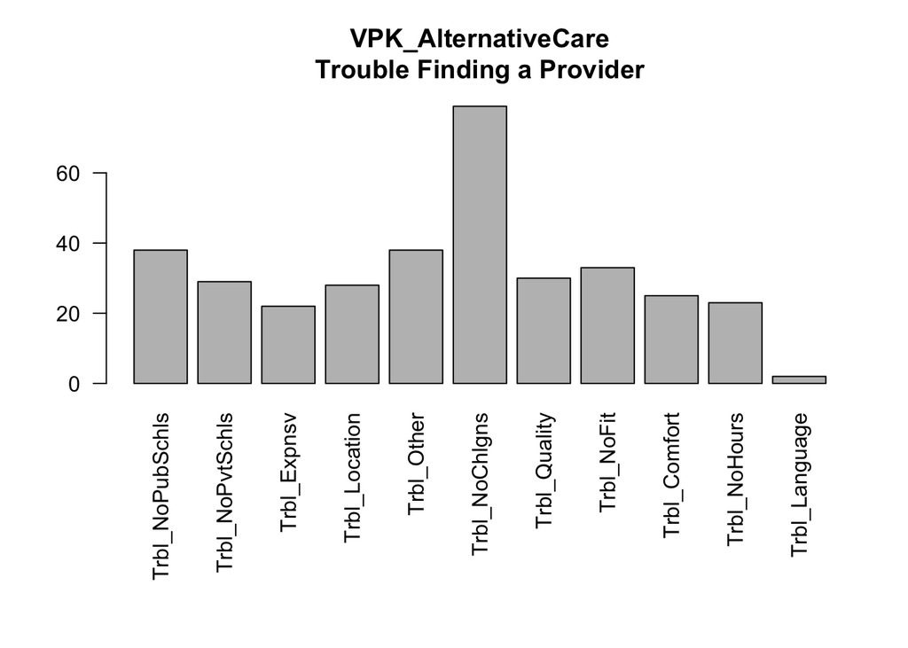

```r
    png("FamFriends_Trouble.png")
    par(mar = c(10.1, 4.1, 4.1, 2.1))
    par(las=2)
    barplot(apply(data$VPKCombined[Sect3Indx,grep("^Trbl",names(data$VPKCombined))], 2, function(c){sum(as.numeric(c),na.rm=TRUE)}))
    dev.off()

    par(mar = c(10.1, 4.1, 4.1, 2.1))
    par(las=2)
    barplot(apply(data$VPKCombined[Sect3Indx,grep("^Trbl",names(data$VPKCombined))], 2, function(c){sum(as.numeric(c),na.rm=TRUE)}), main="VPK_AlternativeCare\nTrouble Finding a Provider")
```

### Discussion with Herman and Phil, 12/5

#### Additional analyses

Adjusted income: Income/# of folks in household-> (range)

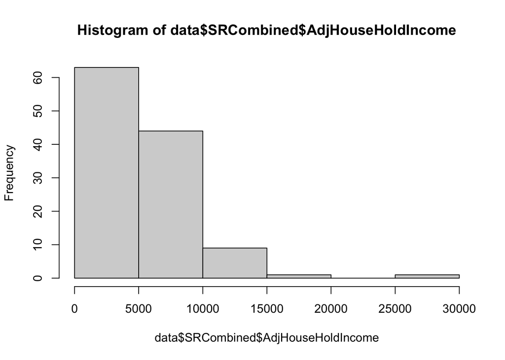

```r
data$SRCombined$AdjHouseHoldIncome=apply(data$SRCombined, 1, function(row){

  if(!any(is.na(row[c("HouseHoldIncome","HouseHoldSize")]))){

    inc=switch(row["HouseHoldIncome"],
      "Less than $14,000"=14000,
      "$100,000 or more"=100000,
      "$15,000 to 19,000"=15000,
      "$20,000 to 29,000"=20000,
      "$30,000 to $39,000"=30000,
      "$40,000 to $49,000"=40000,
      "$50,000 to $74,000"=50000,
      "$75,000 to $100,000"=75000,
      "Prefer not to answer"=NA)

    size=switch(row["HouseHoldSize"],
      "1"=1,
      "2"=2,
      "3"=3,
      "4"=4,
      "5"=5,
      "6+"=6)

    out=as.numeric(inc/size)
  }else{out=NA}
  out
})

hist(data$SRCombined$AdjHouseHoldIncome)
```

```r
summary(data$SRCombined$AdjHouseHoldIncome)
```

```
##    Min. 1st Qu.  Median    Mean 3rd Qu.    Max.    NA's
##    2333    3750    5000    6622    8000   30000      20
```

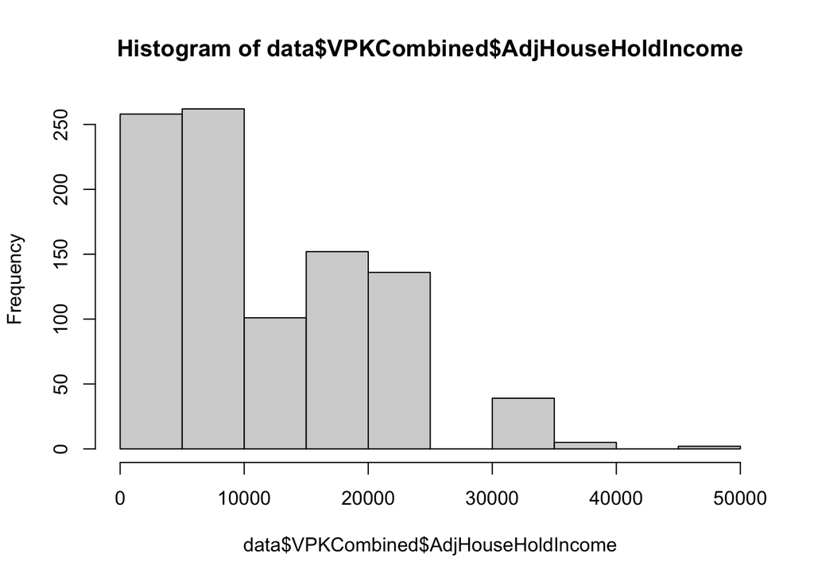

```r
data$VPKCombined$AdjHouseHoldIncome=apply(data$VPKCombined, 1, function(row){

  if(!any(is.na(row[c("HouseHoldIncome","HouseHoldSize")]))){

    inc=switch(row["HouseHoldIncome"],
      "Less than $14,000"=14000,
      "$100,000 or more"=100000,
      "$15,000 to 19,000"=15000,
      "$20,000 to 29,000"=20000,
      "$30,000 to $39,000"=30000,
      "$40,000 to $49,000"=40000,
      "$50,000 to $74,000"=50000,
      "$75,000 to $100,000"=75000,
      "Prefer not to answer"=NA)

    size=switch(row["HouseHoldSize"],
      "1"=1,
      "2"=2,
      "3"=3,
      "4"=4,
      "5"=5,
      "6+"=6)

    out=as.numeric(inc/size)
  }else{out=NA}
  out
})

hist(data$VPKCombined$AdjHouseHoldIncome)
```

```r
summary(data$VPKCombined$AdjHouseHoldIncome)
```

```
##    Min. 1st Qu.  Median    Mean 3rd Qu.    Max.    NA's
##    2333    5000   10000   12903   18750   50000     397
```

Calc -> adjusted to money willing to spend per child (adj range) Price per kid

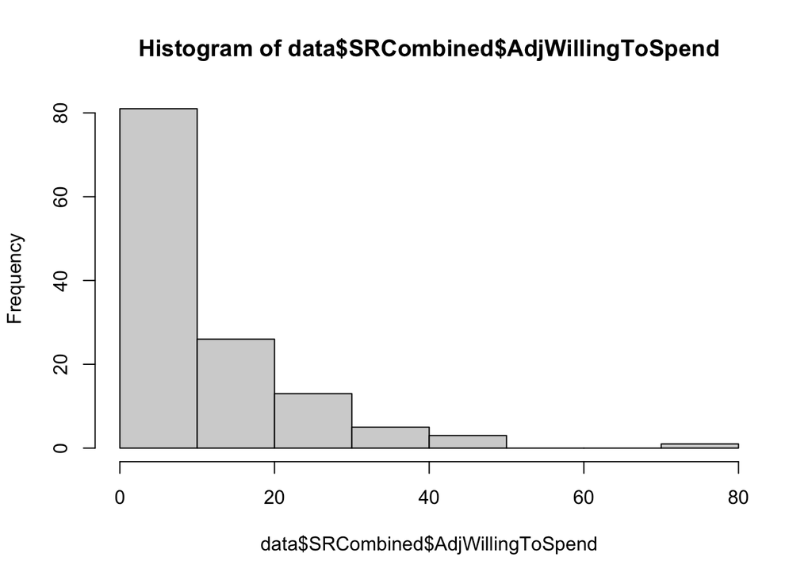

```r
data$SRCombined$AdjWillingToSpend=apply(data$SRCombined, 1, function(row){

  if(!any(is.na(row[c("WillingToSpend","HouseHoldSize")]))){

    spend=switch(unlist(row["WillingToSpend"]),
      "$0-25"=0,
      "$25-50"=25,
      "$50-75"=50,
      "$75-100"=75,
      "$100-150"=100,
      "Greater than $150"=150)

    size=switch(unlist(row["HouseHoldSize"]),
      "1"=1,
      "2"=2,
      "3"=3,
      "4"=4,
      "5"=5,
      "6+"=6)

    out=as.numeric(spend/size)
  }else{out=NA}
  out
})

hist(data$SRCombined$AdjWillingToSpend)
```

```r
summary(data$SRCombined$AdjWillingToSpend)
```

```
##    Min. 1st Qu.  Median    Mean 3rd Qu.    Max.    NA's
##    0.00    0.00    6.25   10.51   15.00   75.00       9
```

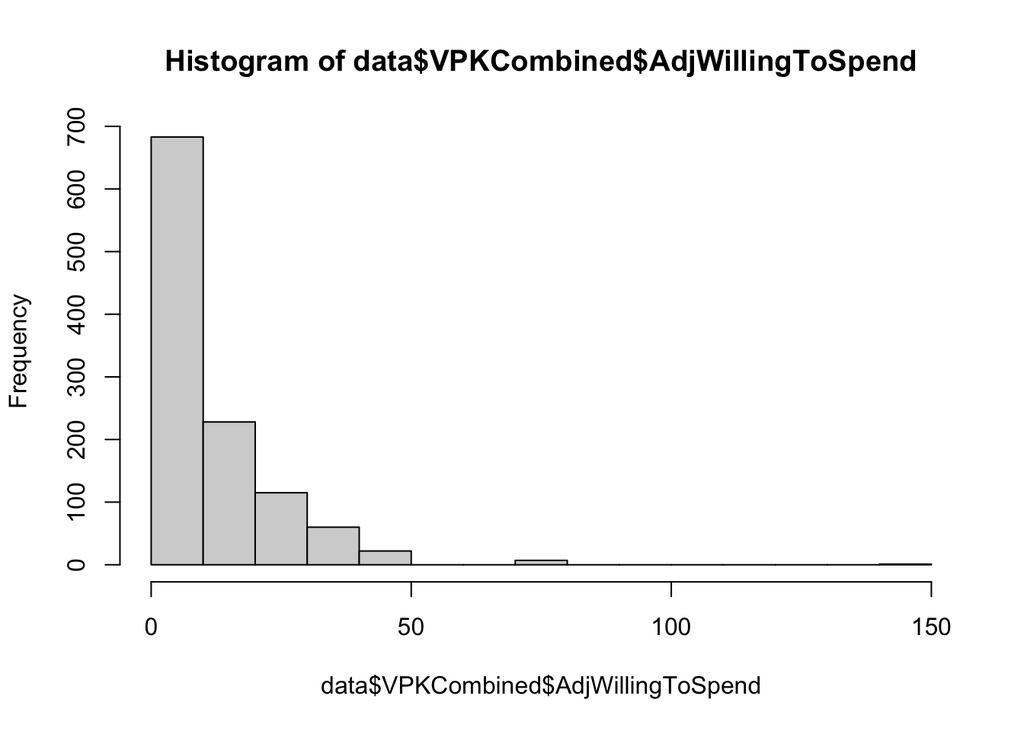

```r
data$VPKCombined$AdjWillingToSpend=apply(data$VPKCombined, 1, function(row){

  if(!any(is.na(row[c("WillingToSpend","HouseHoldSize")]))){

    spend=switch(unlist(row["WillingToSpend"]),
      "$0-25"=0,
      "$25-50"=25,
      "$50-75"=50,
      "$75-100"=75,
      "$100-150"=100,
      "Greater than $150"=150)

    size=switch(unlist(row["HouseHoldSize"]),
      "1"=1,
      "2"=2,
      "3"=3,
      "4"=4,
      "5"=5,
      "6+"=6)

    out=as.numeric(spend/size)
  }else{out=NA}
  out
})

hist(data$VPKCombined$AdjWillingToSpend)
```

```r
summary(data$VPKCombined$AdjWillingToSpend)
```

```
##    Min. 1st Qu.  Median    Mean 3rd Qu.    Max.    NA's
##    0.00    0.00    6.25   11.02   16.67  150.00     236
```

Dig deeper on categories for specific reasons for trouble finding providers (try to identify characteristics)

Trees -> VPK Outcome (Other, Didn’t Experience Challenges, Expensive, public)

```r
      # Trees -> VPK
      #   Outcome (Other, Didn’t Experience Challenges, Expensive, Public)
            table(data$VPKCombined$Trbl_NoChlgns)
```

```
##
##    0    1
## 1119  233
```

```r
            table(data$VPKCombined$Trbl_Expnsv)
```

```
##
##    0    1
## 1182  170
```

```r
            table(data$VPKCombined$Trbl_NoPubSchls)
```

```
##
##   0   1
## 967 385
```

```r
            table(data$VPKCombined$Trbl_Other)
```

```
##
##    0    1
## 1075  277
```

```r
      #   Predictors:
            #Marital status
              table(data$VPKCombined$MaritalStatus)
```

```
##
##                    Divorced/Separated Living with partner in same household
##                                    75                                   104
##                               Married                                Single
##                                   687                                   246
##                               Widowed
##                                     1
```

```r
            #income & adjincome,
              table(data$VPKCombined$HouseHoldIncome)
```

```
##
##     $100,000 or more    $15,000 to 19,000    $20,000 to 29,000
##                  219                   79                   84
##   $30,000 to $39,000   $40,000 to $49,000   $50,000 to $74,000
##                  111                   88                  151
##  $75,000 to $100,000    Less than $14,000 Prefer not to answer
##                  101                  122                  149
```

```r
              table(data$VPKCombined$AdjHouseHoldIncome)
```

```
##
## 2333.33333333333             2500             2800             3000
##               22               10               27               21
## 3333.33333333333             3500             3750             4000
##               15               39               17               18
## 4666.66666666667             5000             6000 6666.66666666667
##               25               64               22               35
##             7000             7500             8000 8333.33333333333
##                7               39               19               28
##            10000            12500 13333.3333333333            14000
##              112               56               15                2
##            15000 16666.6666666667            18750            20000
##               28               54               49               49
##            25000 33333.3333333333            37500            40000
##              136               39                4                1
##            50000
##                2
```

```r
            # of children needing care-> we have # of kids entering KG and HH Size...
              table(data$VPKCombined$NumChildrenEnteringKG)
```

```
##
##            1 child         2 children         3 children         4 children
##               1111                 49                  4                  2
## 5 or more children
##                  4
```

```r
            #preferred amount of money, adjusted
              table(data$VPKCombined$WillingToSpend)
```

```
##
##             $0-25          $100-150            $25-50            $50-75
##               419                90               237               179
##           $75-100 Greater than $150
##               149                77
```

```r
              table(data$VPKCombined$AdjWillingToSpend)
```

```
##
##                0 4.16666666666667                5             6.25
##              401               31               50               89
## 8.33333333333333               10             12.5               15
##               78               34               91               32
## 16.6666666666667            18.75               20               25
##               47               46               12               98
##               30 33.3333333333333             37.5               50
##               17               28               32               22
##               75              150
##                7                1
```

```r
            #transportation,
              table(data$VPKCombined$PrimaryTransportationMode)
```

```
##
##                                        Bicycle
##                                              3
##             Bus or other public transportation
##                                             85
##     Carpool with friends, family, or coworkers
##                                             45
## Paid rideshare (for example: Uber, Lyft, etc.)
##                                             27
##                         Personal motor vehicle
##                                            931
##                                        Walking
##                                             51
```

```r
            #ages of children needing care (collapsing across all ages - one value per row),
              #not in VPK, only in SR
            #parent education
              table(data$VPKCombined$Education)
```

```
##
##                       8th grade or less 9th-12th grade (no high school diploma)
##                                      26                                      58
##               Associate degree (AA, AS)          Bachelor’s degree (BA, BS, AB)
##                                     109                                     252
##         Graduate or professional degree   High school graduate or GED completed
##                                     246                                     195
##       Some college credit but no degree
##                                     215
```

```r
data$VPKCombined$PrimaryTransportationMode[data$VPKCombined$PrimaryTransportationMode=="Walking"]="Walking/Bicycle"
data$VPKCombined$PrimaryTransportationMode[data$VPKCombined$PrimaryTransportationMode=="Bicycle"]="Walking/Bicycle"

data$VPKCombined$MaritalStatus[data$VPKCombined$MaritalStatus=="Living with partner in same household"]="Living with partner in same household/Married"
data$VPKCombined$MaritalStatus[data$VPKCombined$MaritalStatus=="Married"]="Living with partner in same household/Married"

data$VPKCombined$MaritalStatus[data$VPKCombined$MaritalStatus=="Single"]="Widowed/Divorced/Separated/Single"
data$VPKCombined$MaritalStatus[data$VPKCombined$MaritalStatus=="Divorced/Separated"]="Widowed/Divorced/Separated/Single"
data$VPKCombined$MaritalStatus[data$VPKCombined$MaritalStatus=="Widowed"]="Widowed/Divorced/Separated/Single"

data$VPKCombined$NumAdultsHH[data$VPKCombined$MaritalStatus=="Living with partner in same household/Married"]=2
data$VPKCombined$NumAdultsHH[data$VPKCombined$MaritalStatus=="Widowed/Divorced/Separated/Single"]=1



data$VPKCombined$AdultAdjHouseHoldIncome=apply(data$VPKCombined, 1, function(row){

  if(!any(is.na(row[c("HouseHoldIncome","NumAdultsHH")]))){

    inc=switch(row["HouseHoldIncome"],
      "Less than $14,000"=14000,
      "$100,000 or more"=100000,
      "$15,000 to 19,000"=15000,
      "$20,000 to 29,000"=20000,
      "$30,000 to $39,000"=30000,
      "$40,000 to $49,000"=40000,
      "$50,000 to $74,000"=50000,
      "$75,000 to $100,000"=75000,
      "Prefer not to answer"=NA)


    out=as.numeric(as.numeric(inc)/as.numeric(row["NumAdultsHH"]))
  }else{out=NA}
  out
})






d=data$VPKCombined
  for(c in names(d)){
      if(class(d[,c])=="character"){d[,c]=as.factor(d[,c])}
      if(grepl("Trbl",c)){d[,c]=as.factor(d[,c])}
      }

for(v in c("Trbl_NoChlgns", "Trbl_Expnsv", "Trbl_NoPubSchls", "Trbl_Other", "MaritalStatus", "HouseHoldIncome", "AdjHouseHoldIncome", "NumChildrenEnteringKG", "WillingToSpend", "AdjWillingToSpend", "PrimaryTransportationMode", "Education")){
  print(paste0("Variable: ",v,", format -> ",class(d[,v])))

}
```

```
## [1] "Variable: Trbl_NoChlgns, format -> factor"
## [1] "Variable: Trbl_Expnsv, format -> factor"
## [1] "Variable: Trbl_NoPubSchls, format -> factor"
## [1] "Variable: Trbl_Other, format -> factor"
## [1] "Variable: MaritalStatus, format -> factor"
## [1] "Variable: HouseHoldIncome, format -> factor"
## [1] "Variable: AdjHouseHoldIncome, format -> numeric"
## [1] "Variable: NumChildrenEnteringKG, format -> factor"
## [1] "Variable: WillingToSpend, format -> factor"
## [1] "Variable: AdjWillingToSpend, format -> numeric"
## [1] "Variable: PrimaryTransportationMode, format -> factor"
## [1] "Variable: Education, format -> factor"
```

```r
set.seed(27)
#install.packages("partykit")
library(partykit)
#install.packages("party")
library(party)
```

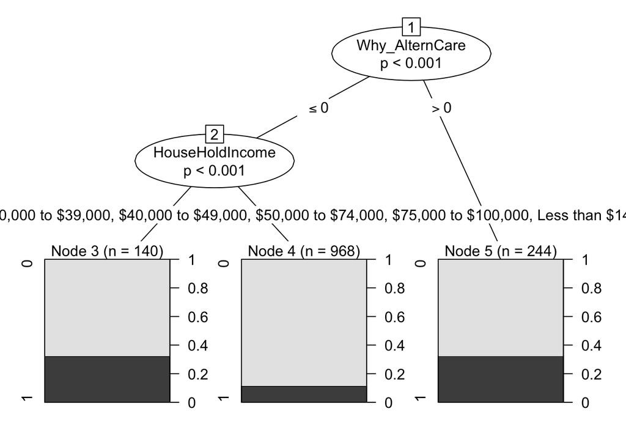

```r
#
# mod.VPK=ctree(Trbl_NoChlgns + Trbl_Expnsv + Trbl_NoPubSchls + Trbl_Other ~  MaritalStatus + HouseHoldIncome + NumChildrenEnteringKG + WillingToSpend2 + PrimaryTransportationMode + Education,
#                    data=d,
#                controls=ctree_control(minbucket=.01*nrow(d)))
# png("out.png",1200,1200)
# plot(mod.VPK)
# dev.off()
#

d$WillingToSpend2=unlist(sapply(d$WillingToSpend, function(x){
  if(!is.na(x)){
    out=switch(
          as.character(x),
          "$0-25"=0 ,
            "$25-50"=1,
          "$50-75"=2,
          "$75-100"=3,
          "$100-150"=4,
          "Greater than $150"=5)}
    else{out=NA}
    out
    }))
#
# ####
# mod.VPK2=ctree(Trbl_NoPubSchls ~  MaritalStatus + HouseHoldIncome + NumChildrenEnteringKG + WillingToSpend2 + PrimaryTransportationMode + Education,
#                    data=d,
#                controls=ctree_control(minbucket=.01*nrow(d)))
#
# ###
# ####
# mod.VPK3=ctree(Trbl_NoPubSchls ~  MaritalStatus + HouseHoldIncome + NumChildrenEnteringKG + WillingToSpend2 + PrimaryTransportationMode,
#                    data=d,
#                controls=ctree_control(minbucket=.01*nrow(d)))
#
# ####
# mod.VPK4=ctree(Trbl_NoPubSchls ~  MaritalStatus + AdultAdjHouseHoldIncome + NumChildrenEnteringKG + WillingToSpend2 + PrimaryTransportationMode,
#                    data=d,
#                controls=ctree_control(minbucket=.01*nrow(d)))
#
# ####
# mod.VPK5=ctree(Trbl_NoPubSchls ~  MaritalStatus + HouseHoldIncome + NumChildrenEnteringKG + WillingToSpend2 + PrimaryTransportationMode,
#                    data=d,
#                controls=ctree_control(minbucket=.01*nrow(d)))
#
# plot(mod.VPK5)
#
# ####
# mod.VPK6=ctree(Trbl_Expnsv ~  MaritalStatus + HouseHoldIncome + NumChildrenEnteringKG + WillingToSpend2 + PrimaryTransportationMode,
#                    data=d,
#                controls=ctree_control(minbucket=.01*nrow(d)))
#
# plot(mod.VPK6)
#
# ####
# mod.VPK7=ctree(Trbl_NoChlgns ~  MaritalStatus + HouseHoldIncome + NumChildrenEnteringKG + WillingToSpend2 + PrimaryTransportationMode + Why_AlternCare + Why_StayFam + Why_StayHome,
#                    data=d,
#                controls=ctree_control(minbucket=.01*nrow(d)))
#
# plot(mod.VPK7)
#
# ####
# mod.VPK8=ctree(Why_AlternCare ~  MaritalStatus + HouseHoldIncome + NumChildrenEnteringKG + WillingToSpend2 + PrimaryTransportationMode + Trbl_NoChlgns,
#                    data=d,
#                controls=ctree_control(minbucket=.01*nrow(d)))
#
# plot(mod.VPK8)
#
# ####
# mod.VPK9=ctree(Why_AlternCare ~  MaritalStatus + HouseHoldIncome + NumChildrenEnteringKG + WillingToSpend2 + PrimaryTransportationMode + Trbl_NoPubSchls  + Trbl_NoPvtSchls + Trbl_Expnsv + Trbl_Location + Trbl_Other + Trbl_NoChlgns + Trbl_Quality + Trbl_NoFit + Trbl_Comfort + Trbl_NoHours + Trbl_Language,
#                    data=d,
#                controls=ctree_control(minbucket=.01*nrow(d)))
#
# plot(mod.VPK9)
#
# ####
# mod.VPK10=ctree(d$Why_StayHome ~  MaritalStatus + HouseHoldIncome + NumChildrenEnteringKG + WillingToSpend2 + PrimaryTransportationMode + Trbl_NoPubSchls  + Trbl_NoPvtSchls + Trbl_Expnsv + Trbl_Location + Trbl_Other + Trbl_NoChlgns + Trbl_Quality + Trbl_NoFit + Trbl_Comfort + Trbl_NoHours + Trbl_Language,
#                    data=d,
#                controls=ctree_control(minbucket=.01*nrow(d)))
#
# plot(mod.VPK10)
#
#
# ####
# mod.VPK11=ctree(d$Why_StayFam ~  MaritalStatus + HouseHoldIncome + NumChildrenEnteringKG + WillingToSpend2 + PrimaryTransportationMode + Trbl_NoPubSchls  + Trbl_NoPvtSchls + Trbl_Expnsv + Trbl_Location + Trbl_Other + Trbl_NoChlgns + Trbl_Quality + Trbl_NoFit + Trbl_Comfort + Trbl_NoHours + Trbl_Language,
#                    data=d,
#                controls=ctree_control(minbucket=5))
#
# plot(mod.VPK11)


#Keep Mod 7 & Mod 9 (below)

mod.VPK7=ctree(Trbl_NoChlgns ~  MaritalStatus + HouseHoldIncome + NumChildrenEnteringKG + WillingToSpend2 + PrimaryTransportationMode + Why_AlternCare + Why_StayFam + Why_StayHome,
                   data=d,
               controls=ctree_control(minbucket=.01*nrow(d)))

plot(mod.VPK7)
```

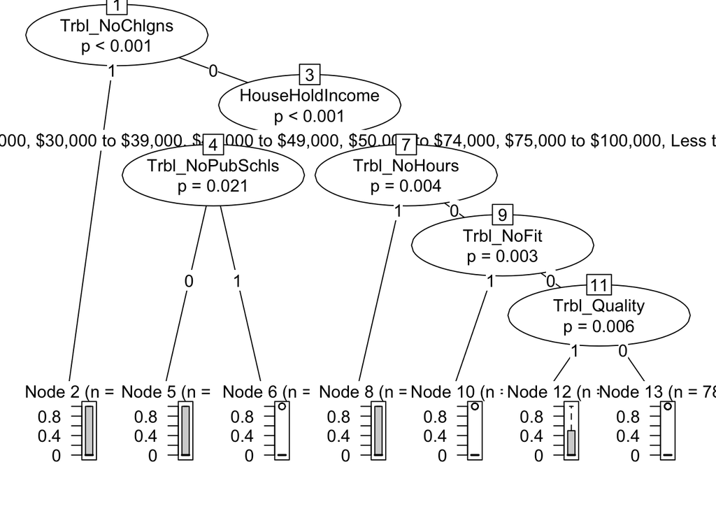

```r
mod.VPK9=ctree(Why_AlternCare ~  MaritalStatus + HouseHoldIncome + NumChildrenEnteringKG + WillingToSpend2 + PrimaryTransportationMode + Trbl_NoPubSchls  + Trbl_NoPvtSchls + Trbl_Expnsv + Trbl_Location + Trbl_Other + Trbl_NoChlgns + Trbl_Quality + Trbl_NoFit + Trbl_Comfort + Trbl_NoHours + Trbl_Language,
                   data=d,
               controls=ctree_control(minbucket=.01*nrow(d)))
plot(mod.VPK9)
```

```r
# png("out10.png",1200,1200)
# plot(mod.VPK10)
# dev.off()
```

```r
temp <- as.POSIXct( unique(data$VPKCombined$ProviderOpensAM) , format = "%H:%M" , tz = "GMT")

t=table(data$VPKCombined$ProviderOpensAM, data$VPKCombined$ProviderClosesPM, useNA = "always")

OpenOrder=unique(data$VPKCombined$ProviderOpensAM)[order(as.POSIXct(unique(data$VPKCombined$ProviderOpensAM) , format = "%H:%M" , tz = "GMT") , decreasing = FALSE )]
ClosedOrder=unique(data$VPKCombined$ProviderClosesPM)[order(as.POSIXct( unique(data$VPKCombined$ProviderClosesPM) , format = "%H:%M" , tz = "GMT"), decreasing = FALSE )]

    png("ProviderOpenAM_Revised.png")
       par(mar = c(12.1, 4.1, 4.1, 2.1))
        par(las=2)
        t=table(data$VPKCombined$ProviderOpensAM)
        b=barplot(t[OpenOrder], ylim=c(0,max(t)*1.2))
        text(b, t[OpenOrder] + max(t)*0.1, t)
      dev.off()
```

```r
  png("ProviderClosedPM_Revised.png")

   par(mar = c(12.1, 4.1, 4.1, 2.1))
        par(las=2)
        t=table(data$VPKCombined$ProviderClosesPM)
        b=barplot(t[ClosedOrder], ylim=c(0,max(t)*1.2))
        text(b, t[ClosedOrder] + max(t)*0.1, t)
      dev.off()
```